# Basic modification of diagrams

## Introduction

We assume you went through the getting started vignette and know the basics of using **flowdiagramr**. In this vignette, you will learn the simplest ways of customizing diagrams. Further vignettes show more advanced approaches.

To re-cap, the simple workflow is like this

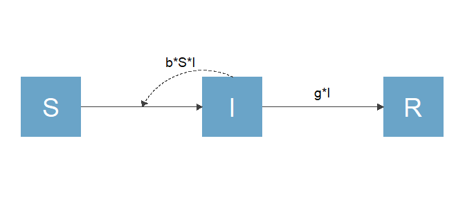

```r
#specify model
mymodel = list( varlabels = c("S","I","R"),
                flows = list(S_flows = c("-b*S*I"),
                             I_flows = c("b*S*I","-g*I"),
                             R_flows = c("g*I"))
              )
#prepare diagram
diagram_list <- prepare_diagram(model_list = mymodel)
#make diagram
my_diagram <- make_diagram(diagram_list = diagram_list)
#plot diagram
plot(my_diagram)
```

Both `prepare_diagram()` and `make_diagram()` can be supplied with additional settings that allow you to customize your diagram rather easily. Let’s look at both.

## Setting arguments in `prepare_diagram()`

You always need to provide a `model_list` input to `prepare_diagram`. In addition, you can provide an optional `model_settings` argument, which allows you to influence the placement of the variables/boxes and arrows. Check the help file with `help('prepare_diagram')` for all the details. Here we explore some of the options through a few examples.

### Example 1

We will explore an extension of the SIR model. For this extension, we also include natural births and deaths. We assume new births only enter the **S** compartment at some fixed flow, **n**, while deaths occur at rate **m** out of all compartments. The model is specified as follows

```r
# specify the model
varlabels = c("S","I","R")
flows = list(S_flows = c("n", "-b*S*I", "-m*S"),
             I_flows = c("+b*S*I","-g*I", "-m*I"),
             R_flows = c("g*I", "-m*R"))
sirmodel = list(varlabels = varlabels, flows = flows)
```

We now specify an additional `model_settings` argument called `varlocations`. This argument is a matrix and should contain the model variables aligned in a grid of rows and columns. This will correspond to their placement in the diagram. In this example, we decided that instead of having all three variables on a single row (the default), we want **S** and **R** on a top row in the left and right corners, and **I** on a row below in the middle.

To accomplish that, we define a grid/matrix with 2 rows and 3 columns and in that matrix, we place the **S** and **R** compartments in the left and right corner of the top row and the **I** compartment in the middle of the bottom row. All other slots are empty, and need to be specified as empty strings. The following code accomplishes that.

```r
#optional list of settings
sirsettings = list(varlocations = matrix(data = c("S", "", "R",
                                                  "", "I", "" ),nrow = 2, ncol = 3, byrow = TRUE)
                  )
```

With these additional settings, the model diagram looks as follows

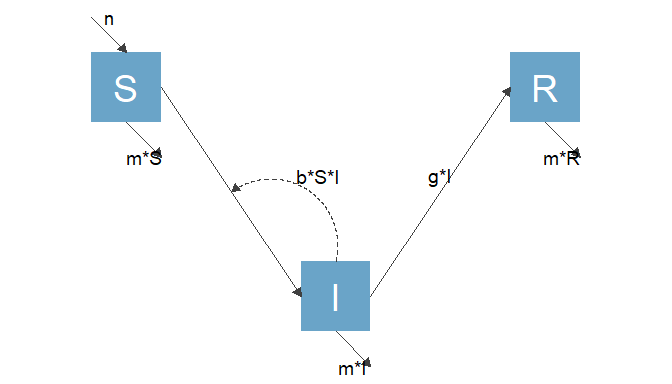

```r
# prepare inputs
sir_diagram_list <- prepare_diagram(model_list = sirmodel, model_settings = sirsettings)
# make  diagram
sir_diagram <- make_diagram(diagram_list = sir_diagram_list)
plot(sir_diagram)
```

For this simple model, the default setting of **flowdiagramr** of having all compartments along a single row would be ok. But unless your model is very simple, you likely do not want all variables/boxes on the same row. Thus, specifying `varlocations` is often very useful and necessary to produce a decent looking diagram.

### Example 2

Let’s look at another example, one that might come up somewhat often, where you need a figure that is mostly vertical. We can do this for the SIR model by again specifying a `varlocations` matrix. In addition, we change the size and spacing of the boxes and space between the boxes here.

```r
sir_vertical_settings = list(varlocations = matrix(data = c("S", "I", "R"), nrow = 3,  byrow = TRUE),
                   varbox_y_size = 0.5,
                   varspace_y_size = 0.5
                   )
```

With this setup, the diagram looks like this

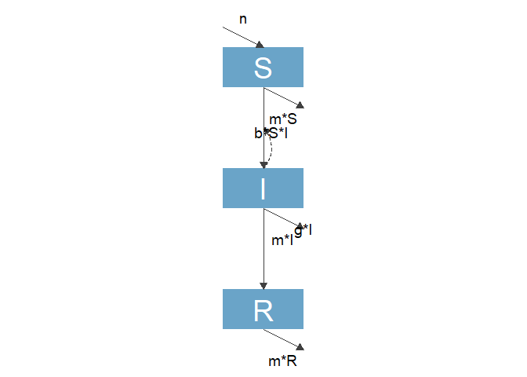

```r
sir_vertical <- prepare_diagram(model_list = sirmodel, model_settings = sir_vertical_settings)
sir_diagram <- make_diagram(diagram_list = sir_vertical)
plot(sir_diagram)
```

```r
ggplot2::ggsave("sirdiagram1.png",sir_diagram)
```

The placement of the flow labels could be improved, which is not hard to do with **flowdiagramr** and you’ll learn that in a future vignette.

**MODEL CHECK. CHANGING Y SCALING HERE ALSO SEEMS TO CHANGE BOX SIZE, LABELS DON’T FIT ANYMORE. CAN ONE MAKE IT SUCH THAT THERE IS NO RELATIVE ADJUSTMENT OF SOME COMPONENTS AS OTHERS CHANGE? SAME ISSUE HAPPENS NOT ONLY FOR FIGURE DISPLAY INSIDE VIGNETTE BUT ALSO WHEN SAVED WITH GGSAVE. ALSO, THE SPACING IN THE VARIABLES DATA FRAME IS NOT RIGHT - SEE BELOW.**

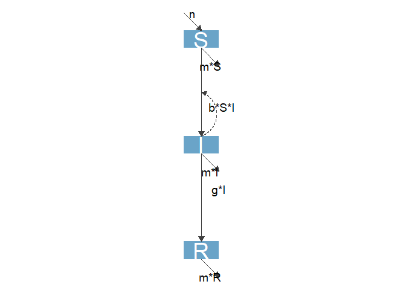

```r
sir_vertical_settings2 = list(varlocations = matrix(data = c("S", "I", "R"), nrow = 3,  byrow = TRUE),
                   varbox_y_size = 0.5,
                   varspace_y_size = 1
                   )
sir_vertical2 <- prepare_diagram(model_list = sirmodel, model_settings = sir_vertical_settings2)
sir_diagram <- make_diagram(diagram_list = sir_vertical2)
plot(sir_diagram)
```

```r
ggplot2::ggsave("sirdiagram2.png",sir_diagram)
```

**ATT: WERE YOU CHANGING THE VARBOX SIZE OR THE VARSPACE SIZE? WHEN I CHANGE varspace_y_size, IT ALL SEEMS TO WORK**

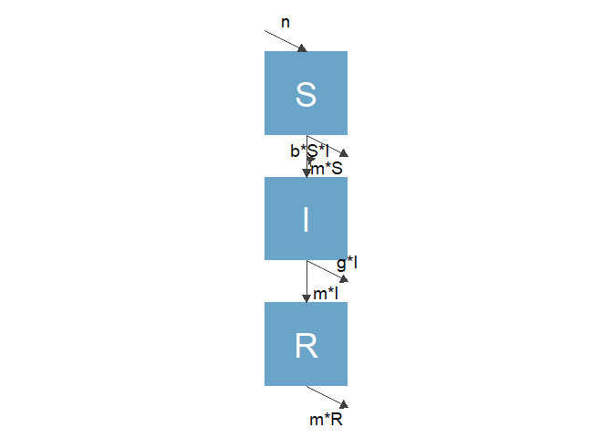

```r
sir_vertical_settings2 = list(varlocations = matrix(data = c("S", "I", "R"), nrow = 3,  byrow = TRUE),
                   varbox_y_size = 1,
                   varspace_y_size = 0.5
                   )
sir_vertical2 <- prepare_diagram(model_list = sirmodel, model_settings = sir_vertical_settings2)
sir_diagram <- make_diagram(diagram_list = sir_vertical2)
plot(sir_diagram)
```

```r
ggplot2::ggsave("sirdiagram2.png",sir_diagram)
print(sir_vertical$variables)
```

```
#>   label id name xmin xmax ymin ymax xlabel ylabel color    fill label_color
#> 1     S  1    S    0    1  3.0  3.5    0.5   3.25    NA #6aa4c8       white
#> 2     I  2    I    0    1  1.5  2.0    0.5   1.75    NA #6aa4c8       white
#> 3     R  3    R    0    1  0.0  0.5    0.5   0.25    NA #6aa4c8       white
#>   label_size
#> 1         10
#> 2         10
#> 3         10
```

```r
print(sir_vertical2$variables)
```

```
#>   label id name xmin xmax ymin ymax xlabel ylabel color    fill label_color
#> 1     S  1    S    0    1  3.0  4.0    0.5    3.5    NA #6aa4c8       white
#> 2     I  2    I    0    1  1.5  2.5    0.5    2.0    NA #6aa4c8       white
#> 3     R  3    R    0    1  0.0  1.0    0.5    0.5    NA #6aa4c8       white
#>   label_size
#> 1         10
#> 2         10
#> 3         10
```

**VECTORIZATION DOES NOT SEEM TO WORK.**

```r
sir_vertical_settings2 = list(varlocations = matrix(data = c("S", "I", "R"), nrow = 3,  byrow = TRUE),
                   varbox_x_size = c(1.5,1,1.5),
                   varbox_y_size = c(0.5,1,0.5),
                   varspace_y_size = c(0.5,1,0.5)
                   )
sir_vertical2 <- prepare_diagram(model_list = sirmodel, model_settings = sir_vertical_settings2)
sir_diagram <- make_diagram(diagram_list = sir_vertical2)
plot(sir_diagram)
ggplot2::ggsave("sirdiagram2.png",sir_diagram)
```

[output not shown]

## Setting arguments in `make_diagram()`

The same idea just shown for `prepare_diagram()` applies to `make_diagram()`. The function can take optional arguments that impact the look of the diagram. The `diagram_list` input is always required. The `diagram_settings` input is optional and gives you a lot of options to quickly change the look of your diagram. Check the help file with `help('make_diagram')` to see all options. We again explore a few options through examples.

We’ll continue with the model from above. First, we call `prepare_diagram` without any additional settings. This produces a list of data frames needed as input for `make_model`. We’ll skip over this step again for now, you’ll learn more about these data frames, and how to potentially modify them, in a later vignette.

```r
# prepare inputs
sir_diagram_list <- prepare_diagram(sirmodel)
```

Now, let’s first produce a basic diagram by calling `make_diagram` with its defaults.

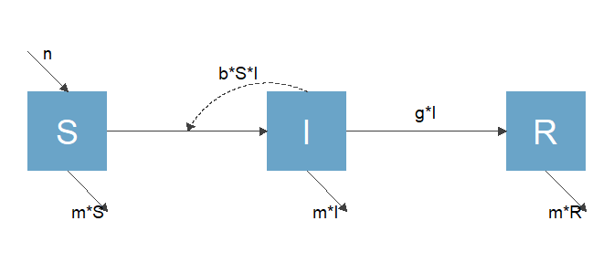

```r
# make a default diagram
default_diagram <- make_diagram(sir_diagram_list)
plot(default_diagram)
```

This looks ok, but maybe you want to make some adjustments. So let’s define some custom settings as a list.

```r
#define settings that change the look of the diagram
sir_diagram_settings <- list(
    var_outline_color = "black",
    var_fill_color = c("#6aa4c8", "#eb5600", "#1a9988"),
    var_label_color = c("black","white","black"),
    var_label_size = c(12,16,12),
    main_flow_color = "blue",
    main_flow_size = c(1,2),
    external_flow_linetype = "dashed",
    external_flow_label_size = c(4,2),
    interaction_flow_color = "red",
    interaction_flow_linetype = "dotted"
    )

# make a diagram with adjusted settings
new_diagram <- make_diagram(
  diagram_list = sir_diagram_list,
  diagram_settings = sir_diagram_settings
  )
```

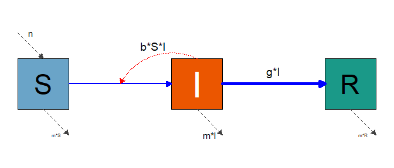

```r
plot(new_diagram)
```

As you can see, it is possible to change the look of the diagram considerably by simply providing custom values to the `make_diagram` input options. All inputs are vectorized. If you provide a single argument, it will be applied to all elements, otherwise the entries in the vector will be applied in the order the variables and flows are listed in the object returned from `prepare_diagram` (which we’ll discuss more in the next vignette.) As an example, `external_flow_label_size = 4` sets all labels for external flows to size 4, while `external_flow_label_size = c(4,2)` set the first external flow to label text to size 4, the next to size 2, then 4 again, etc.

You will note that there is only one type of variable in the optional `diagram_settings` list (labeled `var`), but there are 3 types of flows, namely `main_flow`, `interaction_flow` and `external_flow`. **flowdiagramr** groups flows into those 3 categories. *Main flows* roughly correspond to flows between compartments, *interaction flows* correspond to processes in which variables interact, and *external flows* represent inflows from or outflows to non-modeled entities that are outside the system. **flowdiagramr** tries to guess the types of flows based on the model structure, and might not always place the flows into the same conceptual category that you would. That’s ok since as you will learn later, you can change the appearance of each flow individually. Thus, this grouping is mainly for convenience to let you make modifications to conceptually similar flows in an easy manner.

Let’s look at a few more options that you can configure. By default, **flowdiagramr** shows all flows and labels them all. While it is generally a good idea to show as much information as possible in your diagram, sometimes having too much detail leads to a messy and hard-to-read diagram. In such cases, not showing certain parts of the model might make sense.

You can easily turn on and off the different diagram components. The following code shows an example where we turned off showing the external flows completely, and turn off the labeling of the interaction flows.

Note that if you turn off certain components, any settings that apply styling to those settings will be ignored. You can see that in this example, where we kept some settings for the styling, but since flow labels and external flows are not plotted, any styling applied to them is ignored.

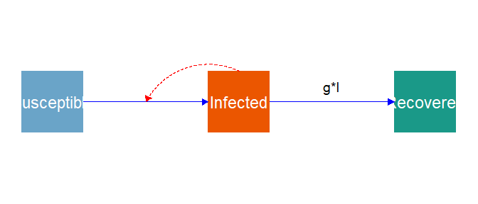

```r
#define settings that remove plotting of all flow labels and inflows/outflows
simpler_diagram_settings <- list(
    var_fill_color = c("#6aa4c8", "#eb5600", "#1a9988"),
    var_label_text = c("Susceptible","Infected","Recovered"),
    var_label_size = 6,
    main_flow_color = "blue",
    external_flow_on = FALSE,
    external_flow_linetype = "dashed", #ignored
    external_flow_label_size = 4, #ignored
    interaction_flow_label_on = FALSE,
    interaction_flow_color = "red")

# make a diagram with adjusted settings
simpler_diagram <- make_diagram(
  diagram_list = sir_diagram_list,
  diagram_settings = simpler_diagram_settings
  )
plot(simpler_diagram)
```

As you can see, the external flows are not shown anymore. We also labeled the boxes with custom names. They don’t quite fit into the boxes. We could either shrink the text size, or increase the box size. We’ll do that in the next section.

## Combining the two approaches

It is of course possible to adjust the look of the diagram by combining the two approaches we just described. Let’s quickly revisit the last example and use the optional settings for `prepare_model` to change the box size.

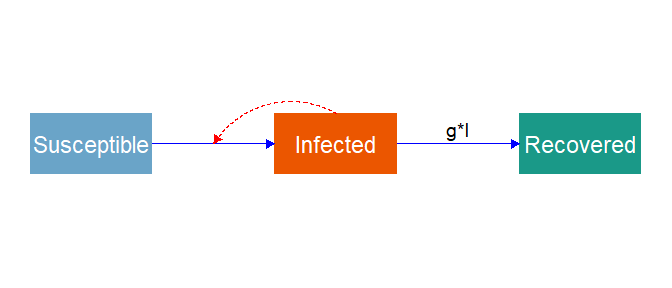

```r
#make the boxes larger
model_settings = list(varbox_x_size = 2)
#prepare diagram with additional optional settings
sir_diagram_list <- prepare_diagram(model_list = sirmodel,
                                    model_settings = model_settings)
#make diagram, using the above optional settings
simpler_diagram_2 <- make_diagram(diagram_list = sir_diagram_list,
                                  diagram_settings = simpler_diagram_settings
                              )
plot(simpler_diagram_2)
```

Let’s look at one more example, the somewhat large model with 7 compartments shown in the *Getting Started* vignette.

Here is the model again.

```r
varlabels = c("Sc","Ic","Rc","Sa","Ia","Ra","P")
flows = list(Sc_flows = c("-Sc*bcc*Ic","-Sc*bca*Ia","-Sc*bcp*P"),
             Ic_flows = c("Sc*bcc*Ic","Sc*bca*Ia","Sc*bcp*P","-gc*Ic"),
             Rc_flows = c("gc*Ic"),
             Sa_flows = c("-Sa*bac*Ic","-Sa*baa*Ia","-Sa*bap*P"),
             Ia_flows = c("Sa*bac*Ic","Sa*baa*Ia","Sa*bap*P","-ga*Ia"),
             Ra_flows = c("ga*Ia"),
             P_flows = c("sc*Ic","sa*Ia","-d*P")
             )
mymodel = list(varlabels = varlabels, flows = flows)
```

This time, we specify locations for the variables. We place the 2 *SIR* compartments on the top and the bottom, and the **P** compartment in the middle. We also resize the boxes so the text we print into the boxes below will fit.

```r
mysettings = list( varlocations = matrix(data = c("Sc", "Ic", "Rc",
                                                  "",   "P",   "",
                                                  "Sa", "Ia", "Ra"),nrow = 3, byrow = TRUE),
                   varbox_x_size = 3,
                   varbox_y_size = 2
                   )
```

This prepares the diagram with those additional settings.

```r
diagram_list <- prepare_diagram(mymodel, mysettings)
```

We also specify some optional settings for `make_diagram()` to influence the look of the diagram. Note the `\n` elements in the text for the variables, this leads to the text being placed on multiple lines.

```r
diagram_settings <- list(
       var_fill_color = c("#6aa4c8", "#eb5600", "#1a9988", "#2987c2", "#e38b59", "#5c948c", "#e8e656"),
       var_label_text = c("Susceptible\nChildren","Infected\nChildren","Recovered\nChildren",
                          "Susceptible\nadults","Infected\nadults","Recovered\nadults",
                          "Pathogen in\nEnvironment"),
       var_label_size = 4,
       interaction_flow_label_size = 4,
       interaction_flow_color = "blue"
       )
```

Now we make the diagram with all these additional settings, the resulting plot looks as follows.

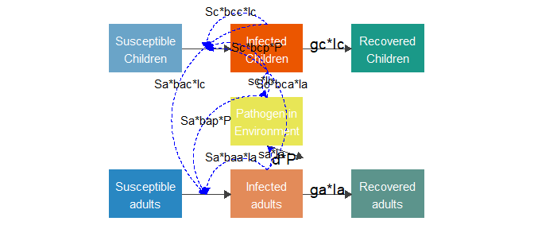

```r
model_plot <- make_diagram(diagram_list, diagram_settings)
plot(model_plot)
```

This is getting better, though not quite publication quality yet. We’ll get there, so read on.

## Recap

Both `prepare_diagram()` and `make_diagram()` take optional arguments that allow you to do a good bit of customizing of the diagrams in a fairly easy manner. The full workflow is as follows

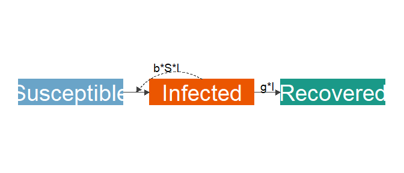

```r
#specify model
mymodel = list( varlabels = c("S","I","R"),
                flows = list(S_flows = c("-b*S*I"),
                             I_flows = c("b*S*I","-g*I"),
                             R_flows = c("g*I"))
              )
#specify extra settings for prepare_diagram
my_model_settings = list(  varbox_x_size = 4,
                           varspace_x_size = 0.5
                        )
#prepare diagram
diagram_list <- prepare_diagram(model_list = mymodel, model_settings = my_model_settings)
#specify extra settings for make_diagram
my_diagram_settings = list(var_fill_color = c("#6aa4c8", "#eb5600", "#1a9988"),
                          var_label_text = c("Susceptible","Infected","Recovered"))
#make diagram
my_diagram <- make_diagram(diagram_list = diagram_list, diagram_settings = my_diagram_settings)
#plot diagram
plot(my_diagram)
```

**NOT QUITE WORKING, ADJUSTING BOX IN X-DIRECTION DOES NOT FIT TEXT**

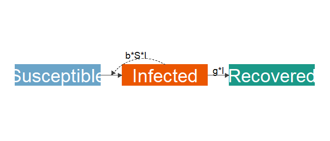

```r
#specify model
mymodel = list( varlabels = c("S","I","R"),
                flows = list(S_flows = c("-b*S*I"),
                             I_flows = c("b*S*I","-g*I"),
                             R_flows = c("g*I"))
              )
#specify extra settings for prepare_diagram
my_model_settings = list(  varbox_x_size = 6,
                           varspace_x_size = 0.5
                        )
#prepare diagram
diagram_list2 <- prepare_diagram(model_list = mymodel, model_settings = my_model_settings)
#specify extra settings for make_diagram
my_diagram_settings = list(var_fill_color = c("#6aa4c8", "#eb5600", "#1a9988"),
                          var_label_text = c("Susceptible","Infected","Recovered"))
#make diagram
my_diagram <- make_diagram(diagram_list = diagram_list, diagram_settings = my_diagram_settings)
#plot diagram
plot(my_diagram)
```

## Next steps

With the approach just discussed, you can modify the look of the diagram a good bit. This might give you a diagram that’s good enough for what you want. However, at times you might want to make further changes. For instance you might want to tweak the placement of the boxes and arrows or add some extra text somewhere on the diagram. **flowdiagramr** gives you ways of doing this.

As a next step toward tweaking the diagram to look exactly the way you want, you can modify the `diagram_list` object produced by the `prepare_diagram` function before sending it to the `make_diagram` function. This gives you additional flexibility in adjusting the model. The next vignette explains how to do that.